# act_report

## Dog Rating Project Wrangling Report

- #### Project Description:

  > In this project we are trying to get some general statistics about dog tweets through the WeRateDogs account on twitter. Through this project data from various sources has been gathered, asessed and the cleaned. To have a fuller view of the data, it was also merged to gain a richer context.
- #### Insights:

  > From Looking through the data there are some interseting *insights* that can be found.
1. The tweet that was most favourited was tweet number 348 in our data which featured a "SUPER SIPPORTIVE PUPPO!", well that can't be a surprise cause puppies are the cutest furry little creatures!
1. The tweet with the most retweets was a funny one featuring a doggo figuring out something for the first time. You can't deny that a good laugh will push you to share content!
1. Looking at our frequency distribution below we can deduce the following:

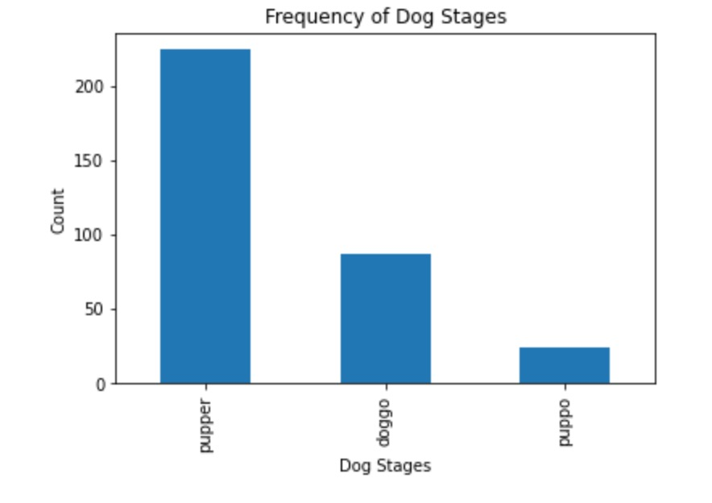

   1. Looking through our dataset and distribution of dog stages we have found that the most dominant presence in our dataset is that of puppers which makes sense as owners tend to take more photos of their cute fury little packages of joy before they grow up!
   2. In second place comes doggos!
   3. In 3rd place comes puppos! By dog owners testimonies this is the hardest phase, you're trying to train your dog, you're running around cleaning up messes and trying to prevent disasters, ehich leaves less time for photography(if you can get them to stay still).
- #### Conclusion:

  > In all cases dogs are the most wonderful creatures and the best of friends. We hope you love dogs as much as we do, if so make sure to follow WeRateDogs to say hello to our furry friends.